# homework5-RA769687

Italo Carvalho Vianelli Ribeiro

23/06/2020

RA: 769687

```r
#install.packages("gtrendsR")
#install.packages("patchwork")
library(gtrendsR)
library(ggplot2)
library(dplyr)
library(patchwork)
```

Exercício 1

No exercício de hoje eu resolvi tanto pesquisar como está a procura de empreendedores passarem a digitalizar para conseguirem realizar vendas de seus negócios durante essa epóca de corona vírus.

Primeiro fiquei curioso em saber o quanto a palavra ‘e-commerce’ foi pesquisada ao longo do tempo no Brasil, e então descobri que a palavra foi muito buscada durante o ínicio do século 21 onde as pessoas passaram a ter computadores domésticos e a utilização da tecnologia se tornou mais popular

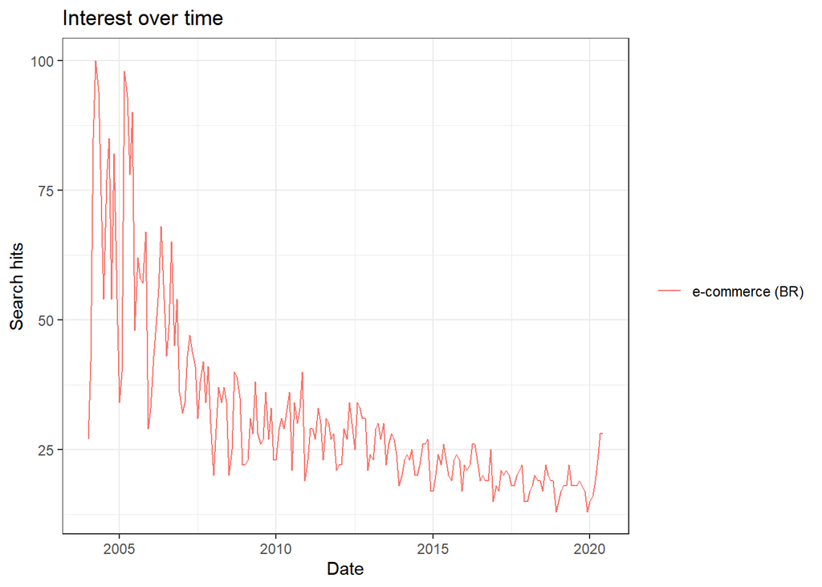

```r
ecommerce <- gtrends(c("e-commerce"), geo = c("BR"), time = "all")
plot(ecommerce)
```

Depois fiz a análise nos últimos meses, e pude perceber que, mesmo oscilando, a procura por e-commerce teve um aumento nos últimos meses com a crise pandêmica

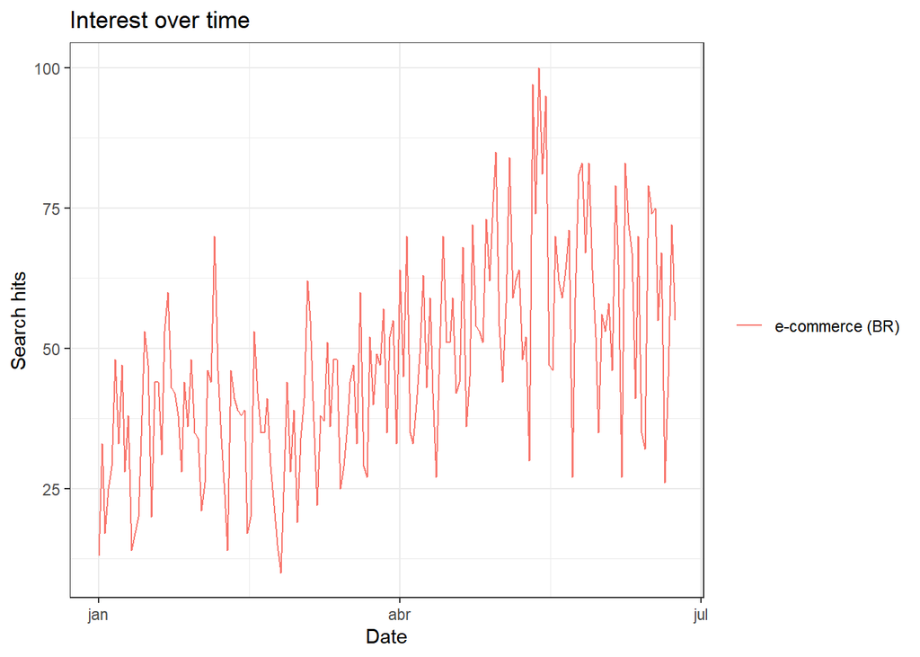

```r
ecommerce2 <- gtrends(c("e-commerce"), geo = c("BR"), time = "2020-01-01 2020-06-23")
plot(ecommerce2)
```

Após isso fiz a análise de pesquisa dos principais aplicativos de entrega: ifood, rappi, delivery much e uber eats. Pode se perceber que a partir do mês de março a busca por esses serviços aumentaram principalmente o rappi que é um aplicativo de entrega de todo tipo de produto

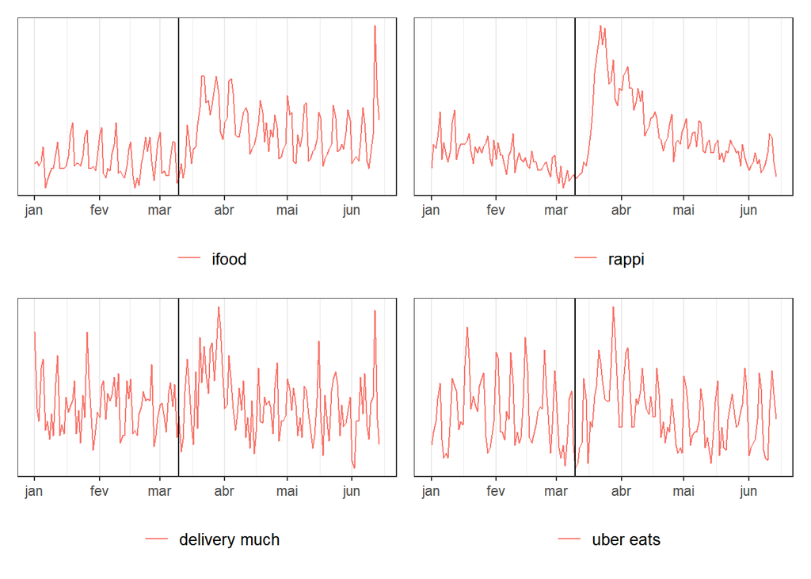

```r
plot_trend<-function(keyword_string){
data<-gtrends(c(keyword_string), time= "2020-01-01 2020-06-14", geo = "BR")
time_trend<-data$interest_over_time %>%
  mutate(hits=ifelse(hits=="<1",0.5,hits),
         date=as.Date(date),
         keyword=factor(keyword, levels = keyword_string))
plot<-ggplot(data=time_trend, aes(x=date, y=as.numeric(hits), colour=keyword)) +
  geom_line() +
  geom_vline(xintercept = as.numeric(as.Date("2020-03-10"))) +
  theme_bw() +
  scale_y_continuous(breaks = NULL) +
  theme(legend.position = "bottom",
        legend.title = element_blank(),
        legend.text=element_text(size=10),
        axis.title.x=element_blank(),
        axis.title.y=element_blank())
return(plot)
}

ifood_plot<-plot_trend(keyword_string = c( "ifood"))
rappi_plot<-plot_trend(keyword_string = c("rappi"))
deliverymuch_plot<-plot_trend(keyword_string = c("delivery much"))
ubereats_plot<-plot_trend(keyword_string = c("uber eats"))

(ifood_plot + rappi_plot) / (deliverymuch_plot + ubereats_plot)
```

Sequencialmente fiz um gráfico comparando a pesquisa dos termos “comércio” e “comércio digital”. E mesmo a pesquisa por comércio digital sendo constante pode-se notar que com a pandêmia do covid-19 busca por criar um comércio teve um aumento bem significativo.

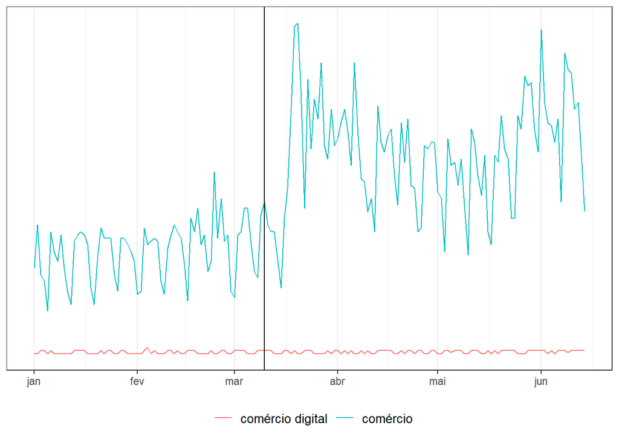

```r
comerciodigital<-plot_trend(keyword_string = c( "comércio digital", "comércio"))
comerciodigital
```

Também realizei um gráfico para poder analizar a procura de criação de site também vem aumentando, mostrando que a procura por digitalizar nesse período de pandemia está aumentando

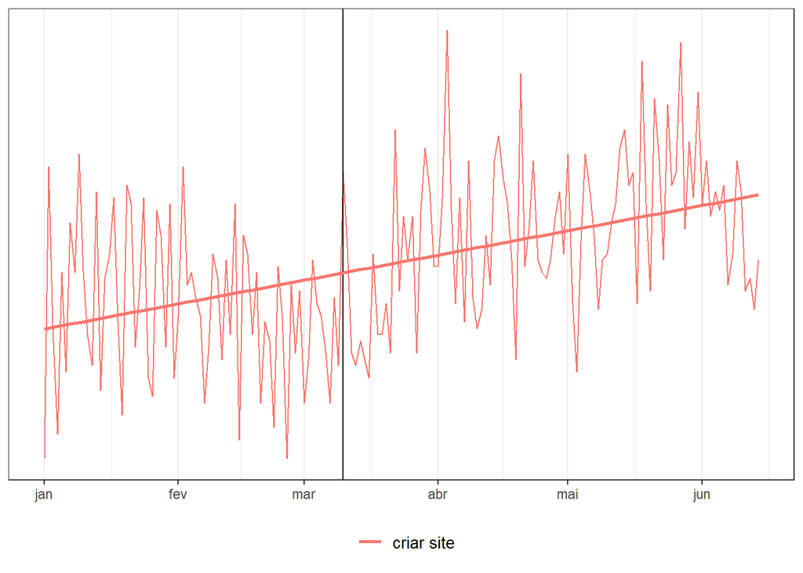

```r
site<-plot_trend(keyword_string = c( "criar site"))+geom_smooth(se = FALSE, method = "lm")
site
```

Por fim realizei um gráfico em relação a procura de “marketing digital”, e posso concluir que com a crise pandemica as pessoas realmente estão indo atás de digitalizar seus negócios, empreender, para sobreviver nesses tempos em que a população precisa estar de quarentena

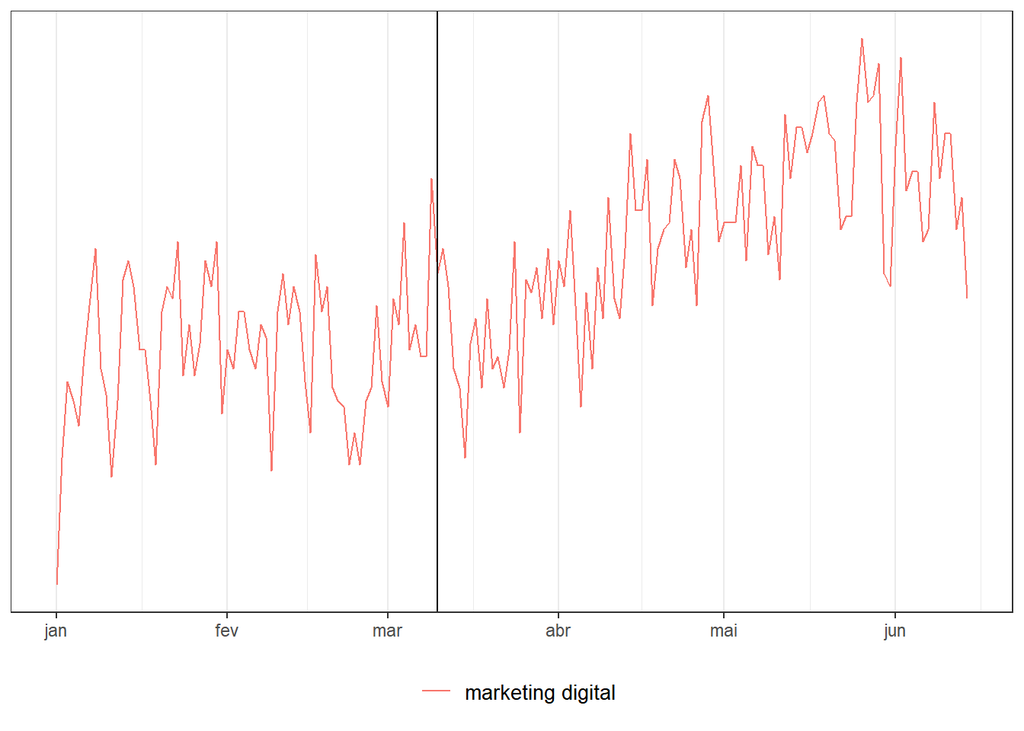

```r
mkt<-plot_trend(keyword_string = c( "marketing digital"))
mkt
```